# Titanic-Project

Jeylan Erman

# Data cleaning

Reading in data:

```r
rm(list=ls())

dir <- "/Users/Jeylan/Documents/Titanic-Project/titanic/"
setwd(dir)

test <- read.csv("test.csv", header=T, as.is=F, na.strings=c("","NA"))
train <- read.csv("train.csv", header=T, as.is=F, na.strings=c("","NA"))
```

Imported libraries.

Now I explore missings.

```r
train$set <- "train"
test$set  <- "test"
test$Survived <- NA
full <- rbind(train, test)

str(full)
```

```
## 'data.frame':    1309 obs. of  13 variables:
##  $ PassengerId: int  1 2 3 4 5 6 7 8 9 10 ...
##  $ Survived   : int  0 1 1 1 0 0 0 0 1 1 ...
##  $ Pclass     : int  3 1 3 1 3 3 1 3 3 2 ...
##  $ Name       : Factor w/ 1307 levels "Abbing, Mr. Anthony",..: 109 191 358 277 16 559 520 629 417 581 ...
##  $ Sex        : Factor w/ 2 levels "female","male": 2 1 1 1 2 2 2 2 1 1 ...
##  $ Age        : num  22 38 26 35 35 NA 54 2 27 14 ...
##  $ SibSp      : int  1 1 0 1 0 0 0 3 0 1 ...
##  $ Parch      : int  0 0 0 0 0 0 0 1 2 0 ...
##  $ Ticket     : Factor w/ 929 levels "110152","110413",..: 524 597 670 50 473 276 86 396 345 133 ...
##  $ Fare       : num  7.25 71.28 7.92 53.1 8.05 ...
##  $ Cabin      : Factor w/ 186 levels "A10","A14","A16",..: NA 82 NA 56 NA NA 130 NA NA NA ...
##  $ Embarked   : Factor w/ 3 levels "C","Q","S": 3 1 3 3 3 2 3 3 3 1 ...
##  $ set        : chr  "train" "train" "train" "train" ...
```

```r
dim(full)
```

```
## [1] 1309   13
```

```r
lapply(full, function(x) length(unique(x)))
```

```
## $PassengerId
## [1] 1309
##
## $Survived
## [1] 3
##
## $Pclass
## [1] 3
##
## $Name
## [1] 1307
##
## $Sex
## [1] 2
##
## $Age
## [1] 99
##
## $SibSp
## [1] 7
##
## $Parch
## [1] 8
##
## $Ticket
## [1] 929
##
## $Fare
## [1] 282
##
## $Cabin
## [1] 187
##
## $Embarked
## [1] 4
##
## $set
## [1] 2
```

```r
summary(full)
```

```
##   PassengerId      Survived          Pclass
##  Min.   :   1   Min.   :0.0000   Min.   :1.000
##  1st Qu.: 328   1st Qu.:0.0000   1st Qu.:2.000
##  Median : 655   Median :0.0000   Median :3.000
##  Mean   : 655   Mean   :0.3838   Mean   :2.295
##  3rd Qu.: 982   3rd Qu.:1.0000   3rd Qu.:3.000
##  Max.   :1309   Max.   :1.0000   Max.   :3.000
##                 NA's   :418
##                                Name          Sex           Age
##  Connolly, Miss. Kate            :   2   female:466   Min.   : 0.17
##  Kelly, Mr. James                :   2   male  :843   1st Qu.:21.00
##  Abbing, Mr. Anthony             :   1                Median :28.00
##  Abbott, Mr. Rossmore Edward     :   1                Mean   :29.88
##  Abbott, Mrs. Stanton (Rosa Hunt):   1                3rd Qu.:39.00
##  Abelson, Mr. Samuel             :   1                Max.   :80.00
##  (Other)                         :1301                NA's   :263
##      SibSp            Parch            Ticket          Fare
##  Min.   :0.0000   Min.   :0.000   CA. 2343:  11   Min.   :  0.000
##  1st Qu.:0.0000   1st Qu.:0.000   1601    :   8   1st Qu.:  7.896
##  Median :0.0000   Median :0.000   CA 2144 :   8   Median : 14.454
##  Mean   :0.4989   Mean   :0.385   3101295 :   7   Mean   : 33.295
##  3rd Qu.:1.0000   3rd Qu.:0.000   347077  :   7   3rd Qu.: 31.275
##  Max.   :8.0000   Max.   :9.000   347082  :   7   Max.   :512.329
##                                   (Other) :1261   NA's   :1
##              Cabin      Embarked       set
##  C23 C25 C27    :   6   C   :270   Length:1309
##  B57 B59 B63 B66:   5   Q   :123   Class :character
##  G6             :   5   S   :914   Mode  :character
##  B96 B98        :   4   NA's:  2
##  C22 C26        :   4
##  (Other)        : 271
##  NA's           :1014
```

```r
##Looking at missings

sapply(full, function(x) {sum(is.na(x))})
```

```
## PassengerId    Survived      Pclass        Name         Sex         Age
##           0         418           0           0           0         263
##       SibSp       Parch      Ticket        Fare       Cabin    Embarked
##           0           0           0           1        1014           2
##         set
##           0
```

```r
full[1:10,]
```

|  | PassengerId | Survived | Pclass | Name | Sex | Age | SibSp | Parch | Ticket | Fare | Cabin | Embarked | set |
| --- | --- | --- | --- | --- | --- | --- | --- | --- | --- | --- | --- | --- | --- |
| 1 | 1 | 0 | 3 | Braund, Mr. Owen Harris | male | 22 | 1 | 0 | A/5 21171 | 7.2500 | NA | S | train |
| 2 | 2 | 1 | 1 | Cumings, Mrs. John Bradley (Florence Briggs Thayer) | female | 38 | 1 | 0 | PC 17599 | 71.2833 | C85 | C | train |
| 3 | 3 | 1 | 3 | Heikkinen, Miss. Laina | female | 26 | 0 | 0 | STON/O2. 3101282 | 7.9250 | NA | S | train |
| 4 | 4 | 1 | 1 | Futrelle, Mrs. Jacques Heath (Lily May Peel) | female | 35 | 1 | 0 | 113803 | 53.1000 | C123 | S | train |
| 5 | 5 | 0 | 3 | Allen, Mr. William Henry | male | 35 | 0 | 0 | 373450 | 8.0500 | NA | S | train |
| 6 | 6 | 0 | 3 | Moran, Mr. James | male | NA | 0 | 0 | 330877 | 8.4583 | NA | Q | train |
| 7 | 7 | 0 | 1 | McCarthy, Mr. Timothy J | male | 54 | 0 | 0 | 17463 | 51.8625 | E46 | S | train |
| 8 | 8 | 0 | 3 | Palsson, Master. Gosta Leonard | male | 2 | 3 | 1 | 349909 | 21.0750 | NA | S | train |
| 9 | 9 | 1 | 3 | Johnson, Mrs. Oscar W (Elisabeth Vilhelmina Berg) | female | 27 | 0 | 2 | 347742 | 11.1333 | NA | S | train |
| 10 | 10 | 1 | 2 | Nasser, Mrs. Nicholas (Adele Achem) | female | 14 | 1 | 0 | 237736 | 30.0708 | NA | C | train |

“Cabin” has the most missings, “Age” also has quite a few missings. “Fare” and “Embarked” have 1 and 2 missings. I will try to impute missings for “Age” after replacing “Fare” with the median and “Embarked” with the mode. I will remove “Cabin” due to the significant number of missings. I will also remove “Ticket” because I don’t expect a relationship with survivorship.

```r
##Removing missings

fmedian <- median(full$Fare, na.rm = TRUE)
full[is.na(full$Fare), "Fare"] <- fmedian

full[is.na(full$Embarked), "Embarked"] <- "S"


full <- select(full, -Cabin, -Ticket)
```

## Variable construction

I will start by imputing “Age” and then creating a categorical variable for age: child vs. adult. There are a lot of zeros in “Parch” but maybe I can combine it with “SibSP” to create a categorical variable for total family size, which can be more meaningful. For “Fare”, I’m going to divide observations equally into four classes, based on Q1, Q2 (median) and Q3. I will create a categorical variable based on “Names” dividing them into those that are prefaced wtih “Miss”, “Mrs”, “Mr” and “other”. This could provide insights on variation within genders.

```r
outlierfilter <- full$Age < boxplot.stats(full$Age)$stats[5]


ageimputemodel <- lm(Age ~ Pclass + Sex + Fare + SibSp + Parch + Embarked, data = full[outlierfilter,])
newdata <- full[is.na(full$Age), c("Pclass", "Sex", "Fare", "SibSp", "Parch", "Embarked")]
full[is.na(full$Age), "Age"] <- predict(ageimputemodel, newdata)

sapply(full, function(x) {sum(is.na(x))})
```

```
## PassengerId    Survived      Pclass        Name         Sex         Age
##           0         418           0           0           0           0
##       SibSp       Parch        Fare    Embarked         set
##           0           0           0           0           0
```

```r
full$agegrp[full$Age < 18] <- "Child"
full$agegrp[full$Age >= 18] <- "Adult"

# There are a lot of zeros in Parch but maybe combined with SibSP it's better
# let's look at the distribution

full$familysize <- full$SibSp + full$Parch + 1


full$faregrp[full$Fare<=7.896] <- "Low"
full$faregrp[full$Fare > 7.896 & full$Fare <= 14.454] <- "Mediuw low"
full$faregrp[full$Fare > 14.454 & full$Fare <= 31.275] <- "Medium"
full$faregrp[full$Fare > 31.275] <- "High"

count(full, 'faregrp')
```

| faregrp | freq |
| --- | --- |
| High | 323 |
| Low | 337 |
| Medium | 339 |
| Mediuw low | 310 |

```r
## Let's do something about names
head(full$Name)
```

```
## [1] Braund, Mr. Owen Harris
## [2] Cumings, Mrs. John Bradley (Florence Briggs Thayer)
## [3] Heikkinen, Miss. Laina
## [4] Futrelle, Mrs. Jacques Heath (Lily May Peel)
## [5] Allen, Mr. William Henry
## [6] Moran, Mr. James
## 1307 Levels: Abbing, Mr. Anthony ... Zakarian, Mr. Ortin
```

```r
full$titles <- gsub("^.*, (.*?)\\..*$", "\\1", full$Name)  ##This code was found online
table(full$Sex, full$titles)
```

```
##
##          Capt Col Don Dona  Dr Jonkheer Lady Major Master Miss Mlle Mme
##   female    0   0   0    1   1        0    1     0      0  260    2   1
##   male      1   4   1    0   7        1    0     2     61    0    0   0
##
##           Mr Mrs  Ms Rev Sir the Countess
##   female   0 197   2   0   0            1
##   male   757   0   0   8   1            0
```

```r
full$titles[full$titles %in% c("Mlle", "Ms")] <- "Miss"
full$titles[full$titles == "Mme"] <- "Mrs"
full$titles[full$titles %in%  c("Capt", "Col", "Don", "Dona", "Dr", "Jonkheer", "Lady", "Major", "Rev", "Sir", "the Countess")] <- "Other"
table(full$Sex, full$titles)
```

```
##
##          Master Miss  Mr Mrs Other
##   female      0  264   0 198     4
##   male       61    0 757   0    25
```

```r
train <- full[full$set == "train", ]
test <- full[full$set == "test", ]
```

## Explore relationships

I will now look at variables descriptively.

```r
## Looking at relationships between variables and Survival

##Tables
table(train[,c('Survived', 'Pclass')])
```

```
##         Pclass
## Survived   1   2   3
##        0  80  97 372
##        1 136  87 119
```

```r
table(train[,c('Survived', 'Sex')])
```

```
##         Sex
## Survived female male
##        0     81  468
##        1    233  109
```

```r
table(train[,c('Survived', 'SibSp')])
```

```
##         SibSp
## Survived   0   1   2   3   4   5   8
##        0 398  97  15  12  15   5   7
##        1 210 112  13   4   3   0   0
```

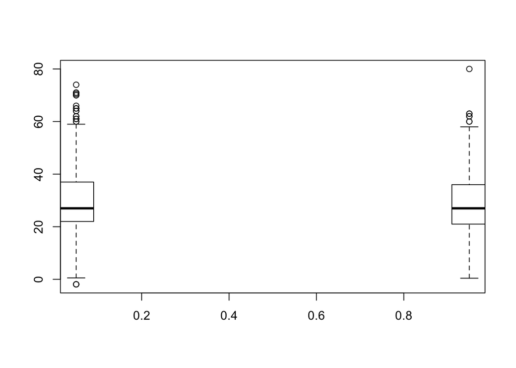

```r
## Box plots
bplot.xy(full$Survived, full$Age)
```

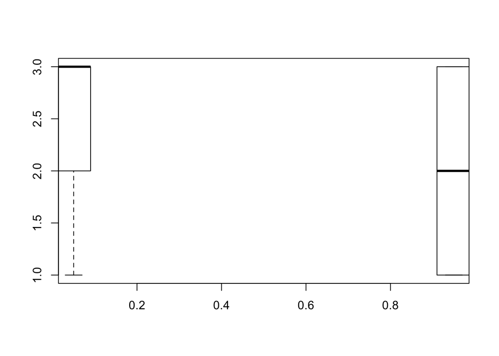

```r
bplot.xy(full$Survived, full$Pclass)
```

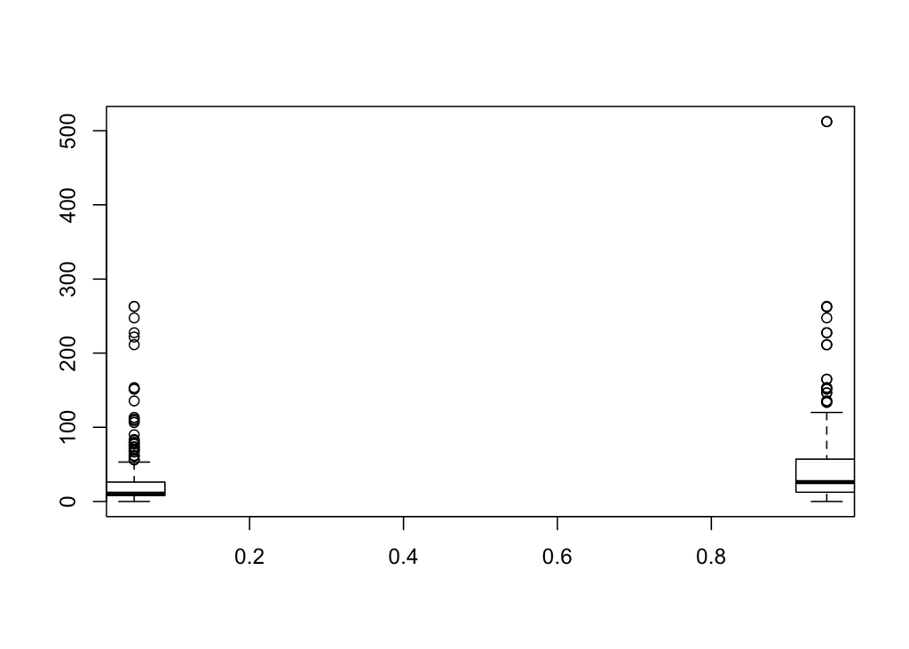

```r
bplot.xy(full$Survived, full$Fare)

bplot.xy(full$Survived, full$Fare)
```

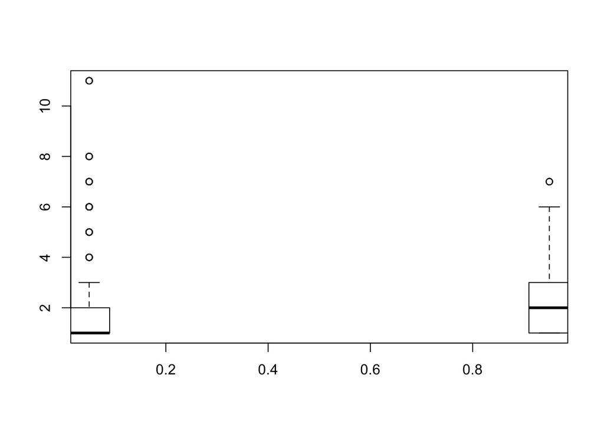

```r
bplot.xy(full$Survived, full$familysize)
```

Family size, class and fare appear important.

## GGplot

I will use GGplot to visualize patterns with more detail.

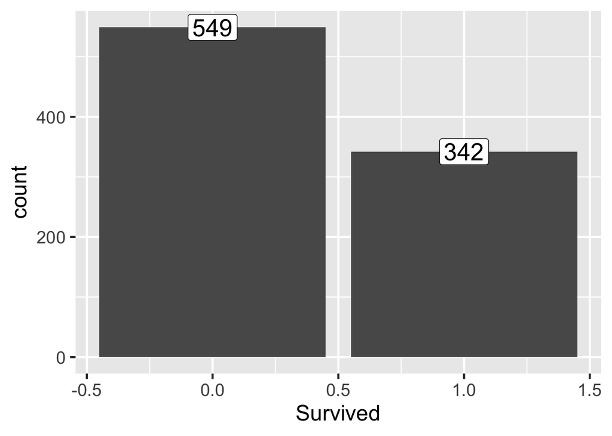

```r
ggplot(full[!is.na(full$Survived),], aes(x = Survived, fill = Survived)) +
  geom_bar(stat='count') +
  geom_label(stat='count',aes(label=..count..), size=7) +
  theme_grey(base_size = 18)
```

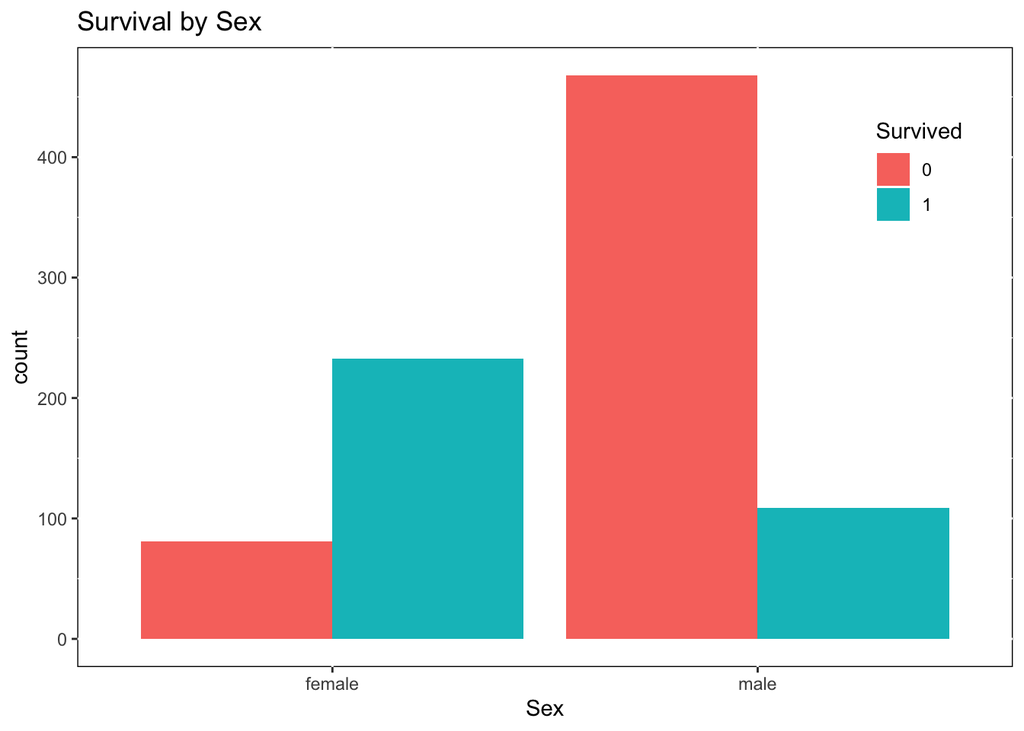

```r
ggplot(train, aes(x = Sex, fill = factor(Survived))) +
  geom_bar(stat = 'count', position = "dodge") +
  labs(x = "Sex", fill = "Survived",
       title = "Survival by Sex") +
  theme(legend.position = c(0.9, 0.8), panel.background = NULL)
```

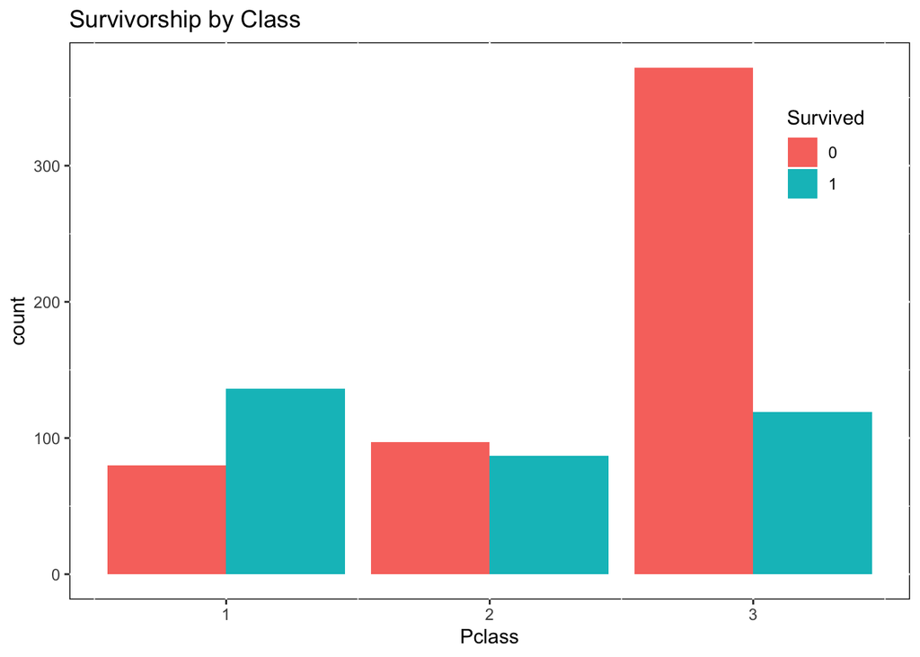

```r
ggplot(train, aes(x = Pclass, fill = factor(Survived))) +
  geom_bar(stat = 'count', position = "dodge") +
  labs(x = "Pclass", fill = "Survived",
       title = "Survivorship by Class") +
  theme(legend.position = c(0.9, 0.8), panel.background = NULL)
```

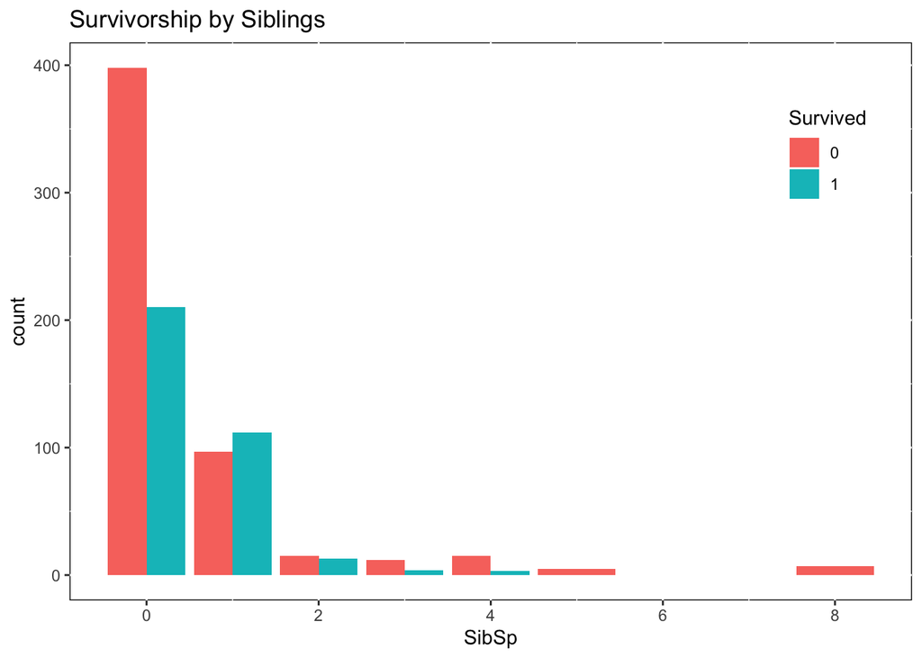

```r
ggplot(train, aes(x = SibSp, fill = factor(Survived))) +
  geom_bar(stat = 'count', position = "dodge") +
  labs(x = "SibSp", fill = "Survived",
       title = "Survivorship by Siblings") +
  theme(legend.position = c(0.9, 0.8), panel.background = NULL)
```

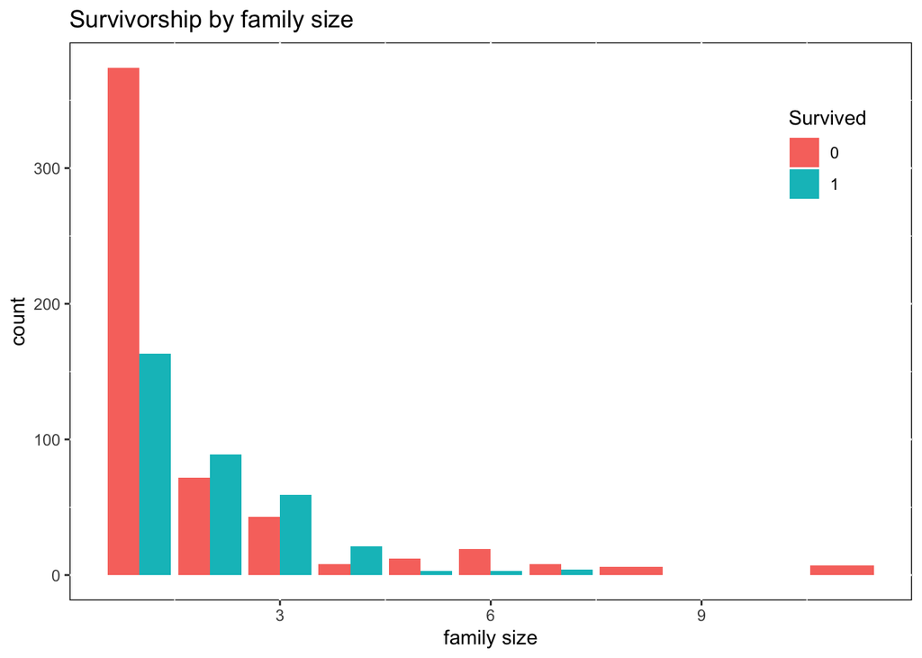

```r
ggplot(train, aes(x = familysize, fill = factor(Survived))) +
  geom_bar(stat = 'count', position = "dodge") +
  labs(x = "family size", fill = "Survived",
       title = "Survivorship by family size") +
  theme(legend.position = c(0.9, 0.8), panel.background = NULL)
```

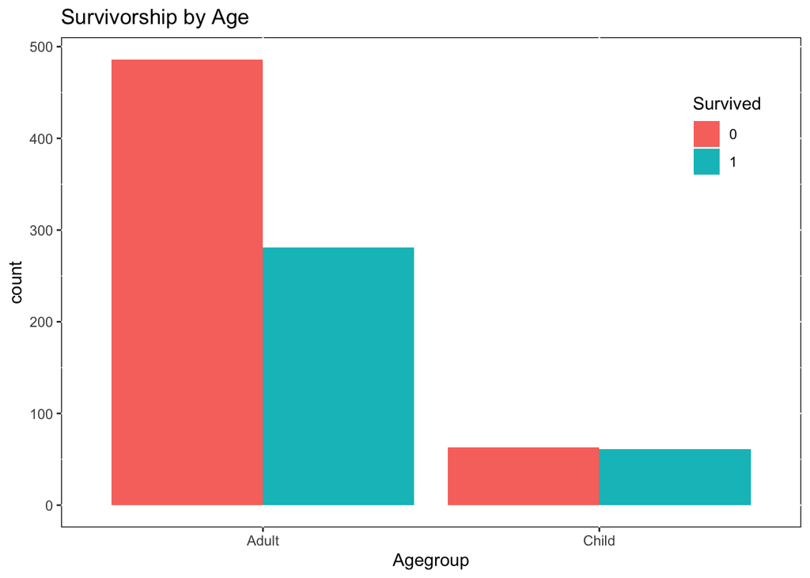

```r
ggplot(train, aes(x = agegrp, fill = factor(Survived))) +
  geom_bar(stat = 'count', position = "dodge") +
  labs(x = "Agegroup", fill = "Survived",
       title = "Survivorship by Age") +
  theme(legend.position = c(0.9, 0.8), panel.background = NULL)
```

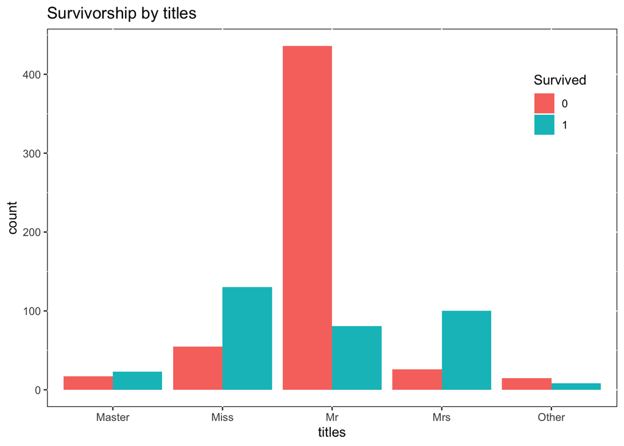

```r
ggplot(train, aes(x = titles, fill = factor(Survived))) +
  geom_bar(stat = 'count', position = "dodge") +
  labs(x = "titles", fill = "Survived",
       title = "Survivorship by titles") +
  theme(legend.position = c(0.9, 0.8), panel.background = NULL)
```

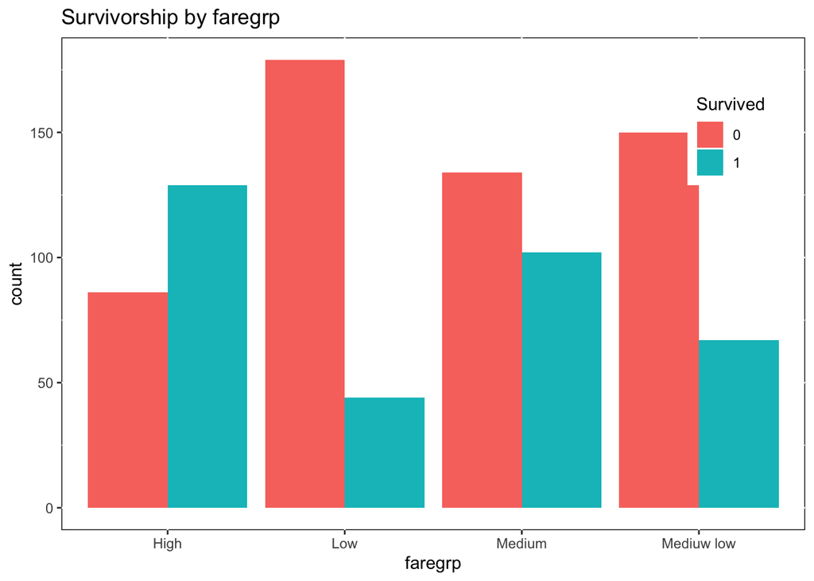

```r
ggplot(train, aes(x = faregrp, fill = factor(Survived))) +
  geom_bar(stat = 'count', position = "dodge") +
  labs(x = "faregrp", fill = "Survived",
       title = "Survivorship by faregrp") +
  theme(legend.position = c(0.9, 0.8), panel.background = NULL)
```

This exploration shows that women were more likely to survive than men, first class was more likely to survival than lower classes, individuals traveling alone were more likely to not survive, adults were less likely to survive than children, men who were masters were more likely to surive than not, every fare group is less likely to surive except those who paid high fares.